# Estudis d'Informàtica, Multimedia i Telecomunicacions

### 2.4.8 Relació entre “exceed” i “occupation”

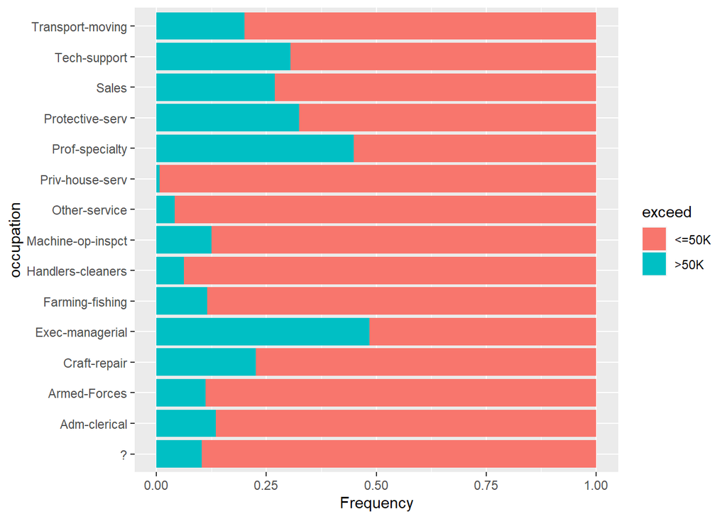

```r
# variable exceed en funció de occupation
ggplot(data=totalData[1:filas,],aes(x=occupation,fill=exceed)) + geom_bar(position="fill") + ylab("Frequency") + coord_flip()
```

Les feines millor remunerades són Exec-managerial (Manager) i Prof-specialty (Professionals Tècnics?). Les pitjor empleats de la llar.

### 2.4.9 Relació entre 3 variables entre “exceed”, “sex”, “race”

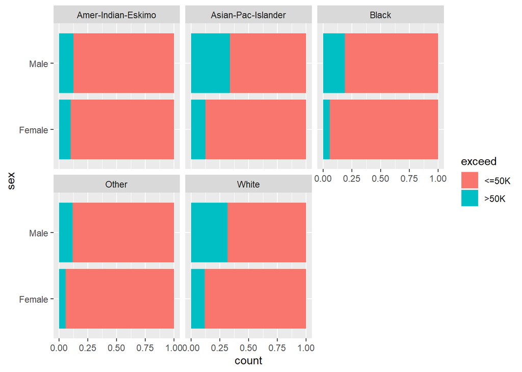

```r
# variable exceed en funció de sex i race
ggplot(data = totalData[1:filas,],aes(x=sex,fill=exceed))+geom_bar(position="fill")+facet_wrap(~race)+ coord_flip()
```

Només en Amer-Indian-Eskimo (Indígenas dels Estados Unidos i esquimals) tenen una proporció similar entre sexe.

### 2.4.10 Relació entre “education” i “workclass” amb un altre histograma

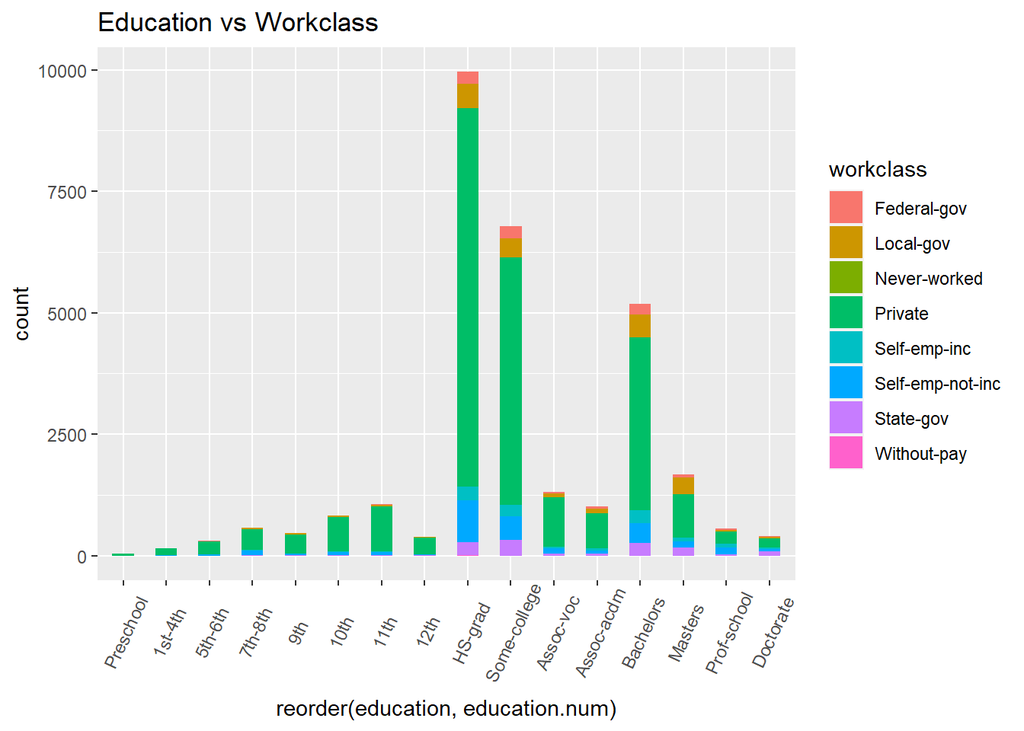

```r
# Primer eliminem els valors buits de workclass
subset <-subset(totalData, workclass != "?")

g <- ggplot(subset, aes(x=reorder(education, education.num)))
g + geom_bar(aes(fill=workclass), width = 0.5) +
  theme(axis.text.x = element_text(angle=65, vjust=0.6)) +
  labs(title="Education vs Workclass")
```

La gran majoria han estudiat fins a HS-grad i treballen en el sector privat.

### 2.4.11 Relació entre “sex” i “workclass” amb un altre histograma

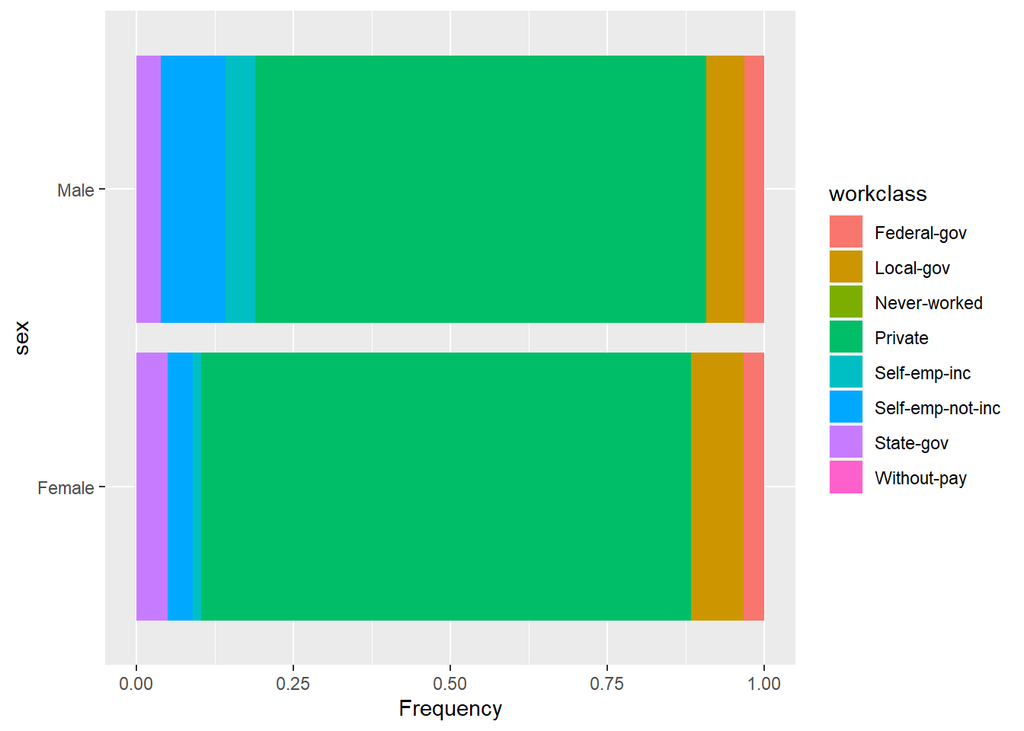

```r
# Primer eliminem els valors buits de workclass
subset <-subset(totalData, workclass != "?")
ggplot(subset,aes(x=sex,fill=workclass), width = 0.5) + geom_bar(position="fill") + ylab("Frequency") + coord_flip()
```

### 2.4.12 Hores a la setmana treballades en funció de la feina realitzada

```r
# eliminem els buits
# eliminem "Without-pay" i "Never-worked"
subset <-subset(totalData, workclass != "?")
subset <-subset(subset, workclass != "Without-pay")
subset <-subset(subset, workclass != "Never-worked")
# creem l'escala d'hores per setmana
min <- min(subset$hours.per.week)
max <- max(subset$hours.per.week)
scale <- abs((min - max) / 10)
str(min)
```

```
##  int 1
```

```r
str(max)
```

```
##  int 99
```

```r
str(scale)
```

```
##  num 9.8
```

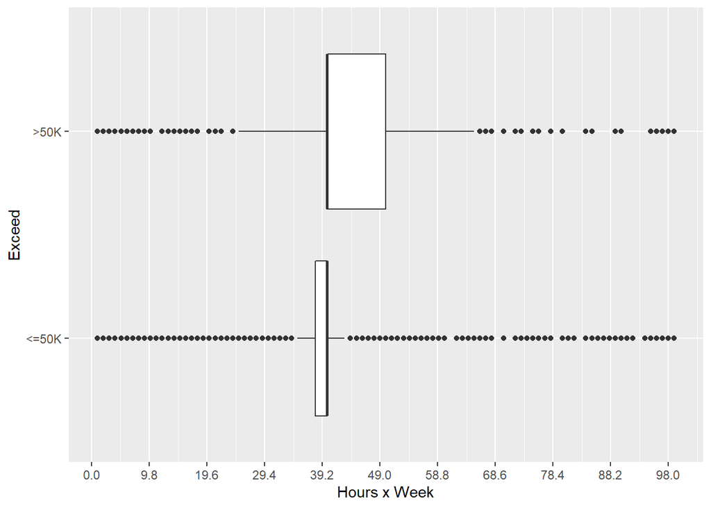

```r
ggplot() + geom_boxplot(subset = iris, aes(x = subset$hours.per.week, y = subset$exceed)) + scale_x_continuous(breaks = seq(from = 0, to = max, scale)) + xlab("Hours x Week") + ylab("Exceed")
```

Es evident que la majoria de gent fa una mitja de 40 hores a la setmana. La gent que té la probabilitat de cobrar més de $50K han de fer mes hores que els que no.

### 2.4.13 Age en funció de ‘finalweight’ -> >$50K

```r
min <- min(totalData$fnlwgt)
max <- max(totalData$fnlwgt)
scale <- abs((min - max) / 5)
str(min)
```

```
##  int 12285
```

```r
str(max)
```

```
##  int 1484705
```

```r
str(scale)
```

```
##  num 294484
```

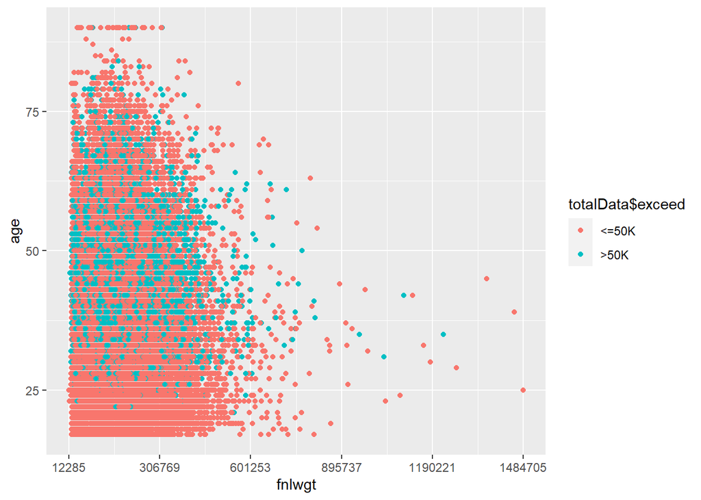

```r
ggplot() + geom_point(totalData = iris, aes(x = totalData$fnlwgt, y = totalData$age, color = totalData$exceed)) +
  scale_x_continuous(breaks = seq(from = min, to = max, scale))  + xlab("fnlwgt") + ylab("age")
```

La gràfica mostra el “fnlwgt” (Final Weight, que defineix conjunst socioeconòmics similars per valors similars) en funció de l’edat, alhora pintant si excedeixen o no. Els punts que excedeixen estan força dispersos en tota la franja de fnlwgt i per edat tornem a veure que es concentren al voltant dels 50.

### 2.4.14 Construcció d’un atribut nou: capital.diff

```r
# Construïm un atribut nou: capital.diff
totalData$capital.diff <- totalData$capital.gain - totalData$capital.loss
subset <- subset(totalData, capital.diff != 0)
str(subset)
```

```
## 'data.frame':    4231 obs. of  17 variables:
##  $ age           : int  39 31 42 43 45 47 30 30 44 30 ...
##  $ workclass     : Factor w/ 9 levels "?","Federal-gov",..: 8 5 5 5 5 5 5 5 5 5 ...
##  $ fnlwgt        : int  77516 45781 159449 117037 386940 51835 188146 59496 343591 117747 ...
##  $ education     : chr  "Bachelors" "Masters" "Bachelors" "11th" ...
##  $ education.num : int  13 14 13 7 13 15 9 13 9 9 ...
##  $ marital.status: Factor w/ 7 levels "Divorced","Married-AF-spouse",..: 5 5 3 3 1 3 3 3 1 3 ...
##  $ occupation    : Factor w/ 15 levels "?","Adm-clerical",..: 2 11 5 15 5 11 8 13 4 13 ...
##  $ relationship  : Factor w/ 6 levels "Husband","Not-in-family",..: 2 2 1 1 4 6 1 1 2 6 ...
##  $ race          : Factor w/ 5 levels "Amer-Indian-Eskimo",..: 5 5 5 5 5 5 5 5 5 2 ...
##  $ sex           : Factor w/ 2 levels "Female","Male": 2 1 2 2 2 1 2 2 1 1 ...
##  $ capital.gain  : int  2174 14084 5178 0 0 0 5013 2407 14344 0 ...
##  $ capital.loss  : int  0 0 0 2042 1408 1902 0 0 0 1573 ...
##  $ hours.per.week: int  40 50 40 40 40 60 40 40 40 35 ...
##  $ native.country: chr  "United-States" "United-States" "United-States" "United-States" ...
##  $ exceed        : Factor w/ 2 levels "<=50K",">50K": 1 2 2 1 1 2 1 1 2 1 ...
##  $ exceed.bool   : logi  FALSE TRUE TRUE FALSE FALSE TRUE ...
##  $ capital.diff  : int  2174 14084 5178 -2042 -1408 -1902 5013 2407 14344 -1573 ...
```

```r
count(subset)
```

```
## # A tibble: 1 x 1
##       n
##   <int>
## 1  4231
```

```r
min <- min(subset$capital.diff)
max <- max(subset$capital.diff)
scale <- abs((min - max) / 5)
str(min)
```

```
##  int -4356
```

```r
str(max)
```

```
##  int 99999
```

```r
str(scale)
```

```
##  num 20871
```

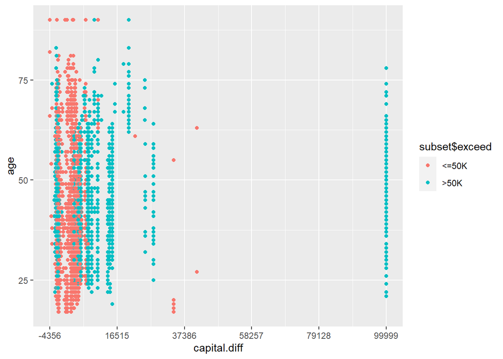

```r
ggplot() + geom_point(subset = iris, aes(x = subset$capital.diff, y = subset$age, color = subset$exceed)) +
  scale_x_continuous(breaks = seq(from = min, to = max, scale)) + xlab("capital.diff") + ylab("age")
```

Sembla que a partir d’una diferència entre ingrés i despesa de capital per sobre d’un valor X (??) tenen moltes possibilitats de tenir uns ingressos per sobre dels $50K.

Anem a esborrar extrems:

```r
# eliminem valors per sobre de 17000
totalData$capital.diff <- totalData$capital.gain - totalData$capital.loss
subset2 <- subset(totalData, capital.diff <= 17000)
str(subset2)
```

```
## 'data.frame':    32306 obs. of  17 variables:
##  $ age           : int  39 50 38 53 28 37 49 52 31 42 ...
##  $ workclass     : Factor w/ 9 levels "?","Federal-gov",..: 8 7 5 5 5 5 5 7 5 5 ...
##  $ fnlwgt        : int  77516 83311 215646 234721 338409 284582 160187 209642 45781 159449 ...
##  $ education     : chr  "Bachelors" "Bachelors" "HS-grad" "11th" ...
##  $ education.num : int  13 13 9 7 13 14 5 9 14 13 ...
##  $ marital.status: Factor w/ 7 levels "Divorced","Married-AF-spouse",..: 5 3 1 3 3 3 4 3 5 3 ...
##  $ occupation    : Factor w/ 15 levels "?","Adm-clerical",..: 2 5 7 7 11 5 9 5 11 5 ...
##  $ relationship  : Factor w/ 6 levels "Husband","Not-in-family",..: 2 1 2 1 6 6 2 1 2 1 ...
##  $ race          : Factor w/ 5 levels "Amer-Indian-Eskimo",..: 5 5 5 3 3 5 3 5 5 5 ...
##  $ sex           : Factor w/ 2 levels "Female","Male": 2 2 2 2 1 1 1 2 1 2 ...
##  $ capital.gain  : int  2174 0 0 0 0 0 0 0 14084 5178 ...
##  $ capital.loss  : int  0 0 0 0 0 0 0 0 0 0 ...
##  $ hours.per.week: int  40 13 40 40 40 40 16 45 50 40 ...
##  $ native.country: chr  "United-States" "United-States" "United-States" "United-States" ...
##  $ exceed        : Factor w/ 2 levels "<=50K",">50K": 1 1 1 1 1 1 1 2 2 2 ...
##  $ exceed.bool   : logi  FALSE FALSE FALSE FALSE FALSE FALSE ...
##  $ capital.diff  : int  2174 0 0 0 0 0 0 0 14084 5178 ...
```

```r
count(subset2)
```

```
## # A tibble: 1 x 1
##       n
##   <int>
## 1 32306
```

```r
min <- min(subset2$capital.diff)
max <- max(subset2$capital.diff)
scale <- abs((min - max) / 25)
str(min)
```

```
##  int -4356
```

```r
str(max)
```

```
##  int 15831
```

```r
str(scale)
```

```
##  num 807
```

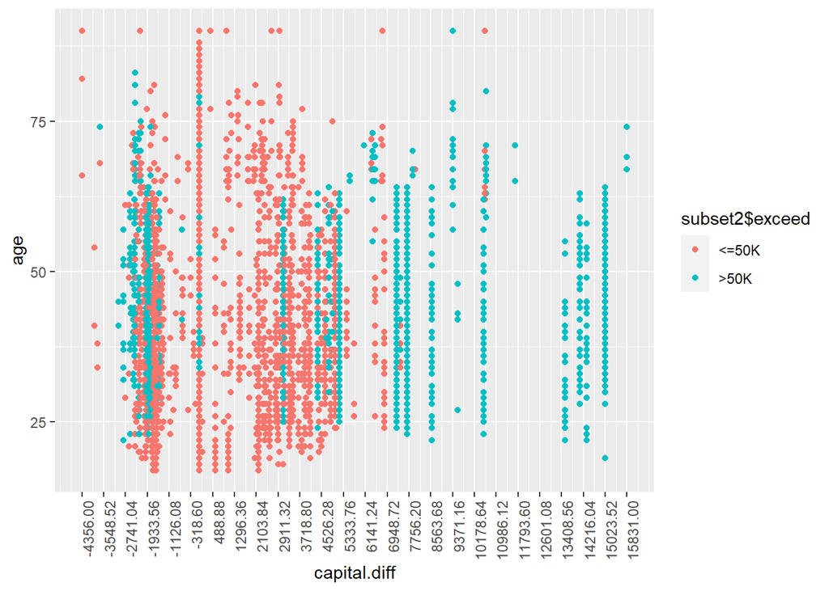

```r
ggplot() + geom_point(subset2 = iris, aes(x = subset2$capital.diff, y = subset2$age, color = subset2$exceed)) +
  scale_x_continuous(breaks = seq(from = min, to = max, scale)) + xlab("capital.diff") + ylab("age") + theme(axis.text.x = element_text(angle = 90, hjust = 1))
```

Curiós perquè a partir del capital.diff d’uns 5000$ la probabilitat es dispara però alhora, els que tenen una capital.diff negatiu per sota de -2000 també.